# Voting and ethnicity in Malaysia

2020-10-08

## Learning Goals

The learning goals for today’s class are as follows:

- Use R-squared to assess predictive power of linear models
- Examine the residuals from linear models
- Think about outliers, leverage, and influence

To achieve these goals, we will spend today’s class analyzing the relationship between voting and ethnicity in the following, recent general elections in Malaysia:

- 2013 General Election
- 2018 General Election

## 2013 General Election

## 2013 General Election

Import `ge2013.csv` as a data frame `ge13` and inspect:

```r
ge13 <- read.csv(file = "ge2013.csv", row.names=1)
str(ge13)
```

```
## 'data.frame':    166 obs. of  10 variables:
##  $ DISTNO  : chr  "P001" "P002" "P003" "P004" ...
##  $ STATE   : chr  "Perlis" "Perlis" "Perlis" "Kedah" ...
##  $ DISTNAME: chr  "PADANG BESAR" "KANGAR" "ARAU" "LANGKAWI" ...
##  $ VOTESBN : int  21473 23343 19376 21407 24161 33334 20654 32263 25491 37923 ...
##  $ VOTESPR : int  14047 19306 18005 9546 20891 22890 16212 36198 27364 42870 ...
##  $ MALAY   : num  83.5 79.3 86.7 91 90.2 ...
##  $ CHINESE : num  11.5 17.7 8.8 6.7 8.2 ...
##  $ INDIAN  : num  1.09 1.84 1.58 2.12 0.06 1.27 0.2 2.28 4.16 1.26 ...
##  $ OTHER   : num  4 1.15 2.92 0.22 1.51 0.43 5.72 0.76 0.33 0.27 ...
##  $ pctBN   : num  60.5 54.7 51.8 69.2 53.6 ...
```

Dataset contains 166 constituency-level observations from the 2013 Malaysian general election. Observations come from the states of peninsular Malaysia (exclude states in East Malaysia).

## 2013 General Election

A codebook with descriptions of the variables and where they were collected were circulated as part of the pre-class materials. However, to review the critical variables for the first half of today’s activity:

- DISTNO and DISTNAME: The constituency number and name
- pctBN: Percent of the votes cast for ruling Barisan Nasional (BN) coalition out of the total number of valid votes cast in the constituency. The BN was in power from independence in 1957 until 2018.

With respect to the ethnic composition of constituencies, the following variables are included:

- MALAY: Percent of voters in the constituency classified as ethnic Malay.
- CHINESE: Percent of voters in the constituency classified as ethnic Chinese.
- INDIAN: Percent of voters in the constituency classified as ethnic Indian.
- OTHER: Percent of voters in the constituency classified as “other” ethnicity (e.g. Eurasian, Thai).

## Challenge 1

Let’s begin out analysis of voting and ethnicity in Malaysia by examining BN vote share and whether it is related to ethnicity.

Working together with your peers, do the following in R:

- Make a histogram of BN Vote Share
- BEFORE making any more plots, discuss the following based on context:
  - What patterns do you expect between BN vote share and ethnicity?
  - How much of the variation in BN vote share would you guess that ethnicity might account for?
  - Why do you expect this to be the case?

Once you are done, we can briefly discuss your answers together.

## Challenge 1 (Solution)

Create a histogram. It appears to show a lot of variation in BN vote share across constituencies.

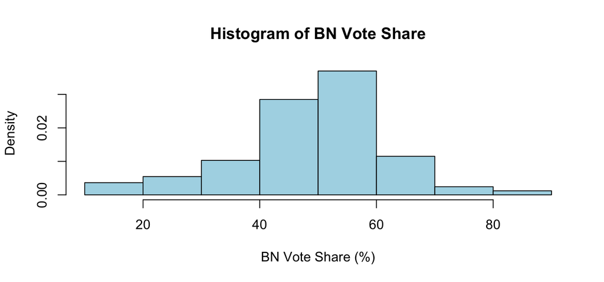

```r
hist(ge13$pctBN, freq=FALSE, col="lightblue",
     main = "Histogram of BN Vote Share",
     xlab = "BN Vote Share (%)")
```

What do you expect to be the relationship between BN vote share and ethnicity? Why?

## Challenge 2

With the patterns you expect to see between BN vote share and ethnicity in mind, let’s now use the ethnic composition of constituencies to predict BN vote shares. Let’s start with the percentages of Malay and Chinese voters.

Working together with your peers, do the following in R:

- Make scatter plots of BN vote shares by the percentage of voters classified as Malay and Chinese
  - Assess which conditions appear to be met for a linear model
- Estimate, interpret, and compare linear models
  - What are the intercepts and slopes? How would you interpret them?
  - What are the R-squares? How would you interpret them?
  - What about the residual standard errors?
- After you estimate the models, make residual plots:
  - What do you find?
  - Can you explain what it means vis-a-vis the conditions for a linear model?

## Challenge 2 (Solution)

Create a scatter plots. Do they match with your intuition?

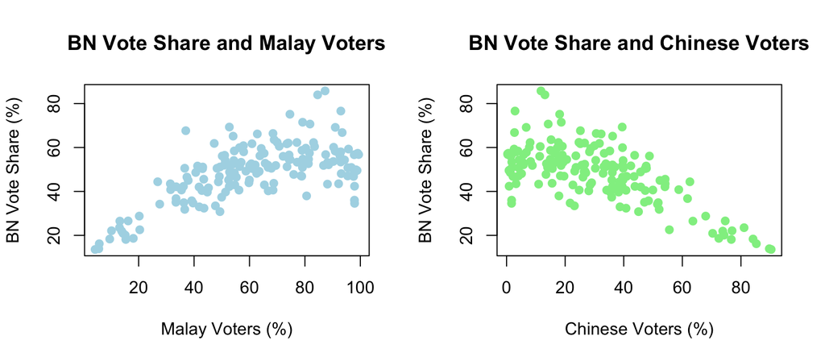

```r
par(mfrow=c(1,2))
plot(pctBN ~ MALAY, data=ge13, col="lightblue", pch=19,
     xlab="Malay Voters (%)", ylab="BN Vote Share (%)",
     main="BN Vote Share and Malay Voters")
plot(pctBN ~ CHINESE, data=ge13, col="lightgreen", pch=19,
     xlab="Chinese Voters (%)", ylab="BN Vote Share (%)",
     main="BN Vote Share and Chinese Voters")
```

## Challenge 2 (Solution)

Estimate linear models:

```r
lm13.BN.MALAY   <- lm(pctBN ~ MALAY, data=ge13)
lm13.BN.CHINESE <- lm(pctBN ~ CHINESE, data=ge13)
```

Now interpret the intercepts and slopes:

```r
coef(lm13.BN.MALAY)  # display intercept & slope
```

```
## (Intercept)       MALAY
##  26.9520696   0.3534643
```

```r
coef(lm13.BN.CHINESE) # display intercept & slope
```

```
## (Intercept)     CHINESE
##   60.873960   -0.412503
```

## Challenge 2 (Solution)

Now interpret the R-squares:

```r
summary(lm13.BN.MALAY)$r.squared # displays r-squared value
```

```
## [1] 0.4398053
```

```r
summary(lm13.BN.CHINESE)$r.squared # displays r-squared value
```

```
## [1] 0.455778
```

Which model best accounts for the variation in BN vote share? Why?

## Challenge 2 (Solution)

What about the residual standard errors?

```r
sd(lm13.BN.MALAY$residuals) # displays r-squared value
```

```
## [1] 9.812739
```

```r
sd(lm13.BN.CHINESE$residuals) # displays r-squared value
```

```
## [1] 9.671834
```

Which model best accounts for the variation in BN vote share? Why?

## Challenge 2 (Solution)

Create a residual plots. What does it mean vis-a-vis the conditions for a linear model?

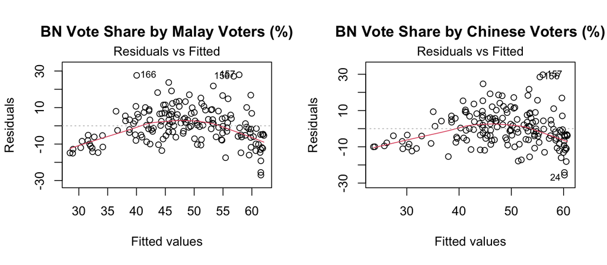

```r
par(mfrow=c(1,2))
plot(lm13.BN.MALAY, which=1,
     main = "BN Vote Share by Malay Voters (%)",
     sub.caption = "BN Vote Share (%)")
plot(lm13.BN.CHINESE, which=1,
     main = "BN Vote Share by Chinese Voters (%)",
     sub.caption = "BN Vote Share (%)")
```

## Challenge 2 (Solution)

The violation of the straight enough condition is also clear if we add the line of best fit.

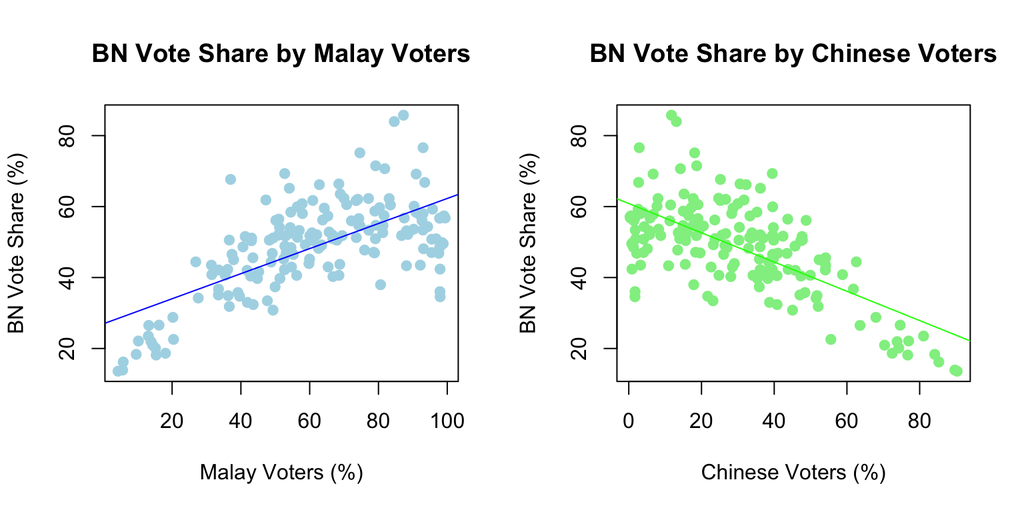

## Discussion

Let’s take a moment to pause, think, and talk about the models so far:

- What have we found?
  - Positive relationship between percent Malay voters and BN vote share
  - Negative relationship between percent Chinese voters and BN vote share
  - `CHINESE` more predictive of BN vote share than `MALAY`
  - Residuals suggest relationship not strictly linear
- Things to think about:
  - Did you expect `CHINESE` to be more predictive than `MALAY`
  - What might explain the curve in the relationship?
    - What further might we do to find out?

## 2018 General Election

## 2018 General Election

For today’s second half of today’s activity, we will be using the dataset `ge2018.csv` to practice fitting and assessing linear models.

To provide some background on the 2018 general election:

- Fought largely between the Barisan Nasional (BN) coalition and the opposition Pakatan Harapan (PH) coalition
  - BN led by Prime Minister Najib Razak
  - PH led by former Prime Minister Mahathir Mohamad
- Election played out against backdrop of a major scandal over embezzlement funds from Malaysia’s 1MDB sovereign wealth fund (Najib accused of taking USD 700 million - currently on trial)
- The PH coalition defeated the BN
  - First non-BN/UMNO-led government since Malaysia’s independence in 1957
  - Transition raised hopes of a *Malaysia Baru* (a new Malaysia) and that the country could potentially move beyond the politics of race/ethnicity that had dominated since independence

## 2018 General Election

Import `ge2018.csv` as a data frame `ge18` and inspect:

```r
ge18 <- read.csv("ge2018.csv")
str(ge18)
```

```
## 'data.frame':    222 obs. of  12 variables:
##  $ DISTNO  : chr  "P001" "P002" "P003" "P004" ...
##  $ STATE   : chr  "Perlis" "Perlis" "Perlis" "Kedah" ...
##  $ DISTNAME: chr  "PADANG BESAR" "KANGAR" "ARAU" "LANGKAWI" ...
##  $ VOTESBN : int  15032 15306 16547 10061 12413 16975 16384 18390 14181 19400 ...
##  $ VOTESPH : int  13594 20909 11691 18954 18695 29984 7254 28959 32475 36624 ...
##  $ VOTERS  : int  46096 55938 48187 42697 54132 73881 46644 86892 80272 97753 ...
##  $ TURNOUT : int  37432 45703 40433 35250 44822 61452 39932 71910 65096 80555 ...
##  $ AREA    : int  450 141 222 469 316 634 1357 322 111 233 ...
##  $ BUMI    : num  0.876 0.819 0.878 0.907 0.913 0.869 0.922 0.816 0.637 0.783 ...
##  $ CHINESE : num  0.085 0.152 0.077 0.065 0.069 0.085 0.013 0.155 0.317 0.203 ...
##  $ INDIAN  : num  0.009 0.017 0.017 0.024 0.001 0.035 0.002 0.025 0.042 0.011 ...
##  $ OTHER   : num  0.031 0.012 0.029 0.004 0.017 0.012 0.064 0.005 0.004 0.003 ...
```

Dataset includes 222 observations for all constituencies. Includes constituencies from peninsular Malaysia as well as from the East Malaysian states of Sabah and Sarawak.

## Challenge 1

Let’s start by replicating the main analysis for 2013 using the 2018 data.

Working together with your peers, do the following in R:

- Make a histogram of BN Vote Share
  - Notice that the dataset does not contain a variable `pctBN`
  - So create `pctBN` using `VOTESBN` and `TURNOUT`, and append
- Make a scatter plot of BN Vote Share by the proportion of voters classified as Bumiputera
  - Assess which conditions appear to be met for a linear model
- Estimate linear models for BN Vote Share and all ethnicities
  - Which model has the highest predictive power?
  - Is it the same as in the 2013 general election?

## Challenge 1 (Solution)

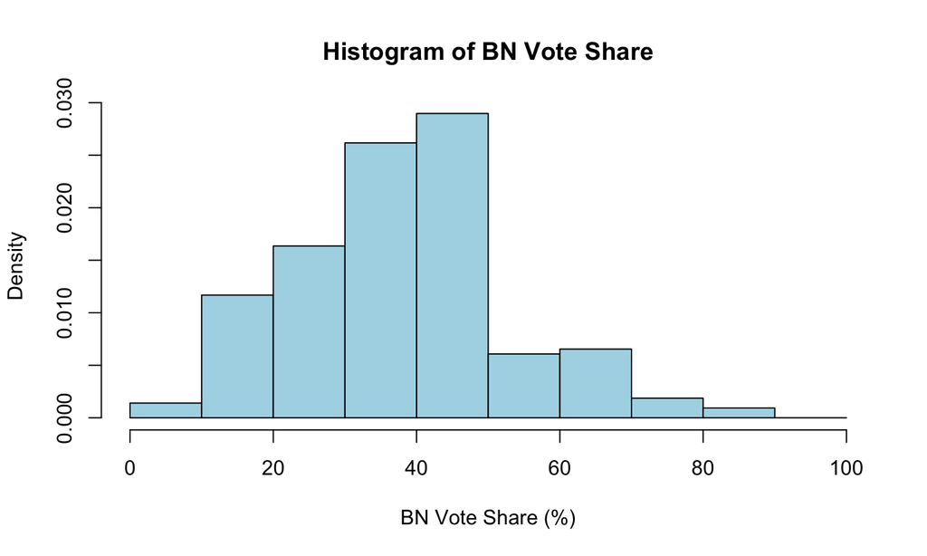

```r
ge18$pctBN <- 100 * (ge18$VOTESBN/ge18$TURNOUT) # compute pctBN and append
hist(ge18$pctBN, freq=FALSE, col="lightblue", breaks=seq(0, 100, 10),
     main = "Histogram of BN Vote Share",
     xlab = "BN Vote Share (%)")
```

## Challenge 1 (Solution)

Create a scatter plot of BN Vote Share versus the proportion classified as Bumiputera.

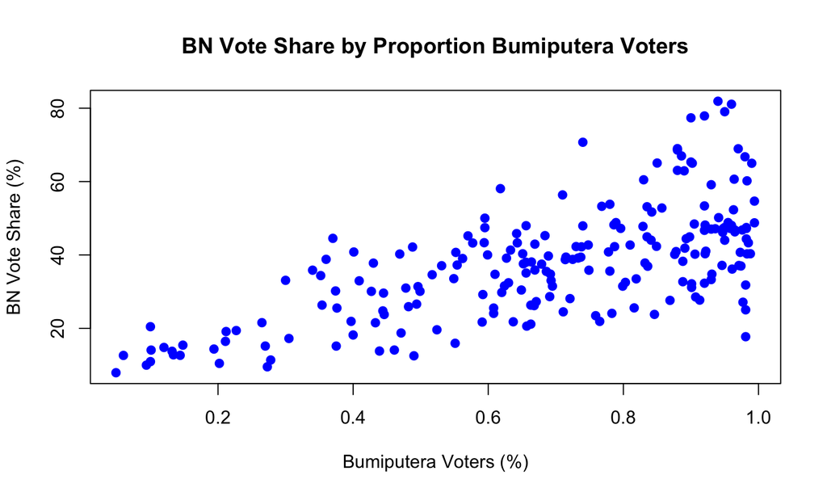

```r
plot(pctBN ~ BUMI, data=ge18, col="blue", pch=19,
     xlab="Bumiputera Voters (%)", ylab="BN Vote Share (%)",
     main="BN Vote Share by Proportion Bumiputera Voters")
```

## Challenge 1 (Solution)

Estimate linear models for BN vote share and each ethnicity:

```r
lm18.BN.BUMI    <- lm(pctBN ~ BUMI,    data=ge18)
lm18.BN.CHINESE <- lm(pctBN ~ CHINESE, data=ge18)
lm18.BN.INDIAN  <- lm(pctBN ~ INDIAN,  data=ge18)
lm18.BN.OTHER   <- lm(pctBN ~ OTHER,   data=ge18)
```

Check the model output for `CHINESE` in both 2018 and in 2013 to see if slope is similar:

```r
coef(lm18.BN.CHINESE)
```

```
## (Intercept)     CHINESE
##    48.48178   -43.26668
```

```r
coef(lm13.BN.CHINESE)
```

```
## (Intercept)     CHINESE
##   60.873960   -0.412503
```

## Challenge 1 (Solution)

Check which model has highest predictive power. Bumiputera has the highest predictive power.

```r
summary(lm18.BN.BUMI)$r.squared
```

```
## [1] 0.4411699
```

```r
summary(lm18.BN.CHINESE)$r.squared
```

```
## [1] 0.3768821
```

```r
summary(lm18.BN.INDIAN)$r.squared
```

```
## [1] 0.2143789
```

```r
summary(lm18.BN.OTHER)$r.squared
```

```
## [1] 0.009243599
```

## Challenge 2

What about the relationship between the opposition Pakatan Harapan (PH) coalition’s vote share and ethnicity in 2018?

Working together with your peers, do the following in R:

- Make a histogram of PH Vote Share
  - Create `pctPH` using `VOTESPH` and `TURNOUT`, then append
  - Also, combine with a histogram of BN vote share to compare variation
- Make a scatter plot of PH Vote Share by the proportion of voters classified as Bumiputera
  - Assess which conditions appear to be met for a linear model
- Estimate linear models for PH Vote Share and all ethnicities
  - Which model has the highest predictive power?

Compare the results you obtained against those for the Barisan Nasional (BN), and take a moment to think about what they tell you regarding voting and ethnicity in the 2018 General Election

## Challenge 2 (Solution)

Create `pctPH` and make histograms of PH Vote Share and BN vote shares

```r
ge18$pctPH <- 100 * (ge18$VOTESPH / ge18$TURNOUT) # create pctPH and append
```

Create histograms of BN and PH vote shares:

```r
par(mfrow=c(1,2))

hist(ge18$pctBN, freq=FALSE, col="lightblue", breaks=seq(0, 100, 10),
  main = "Histogram of BN Vote Shares",
  xlab = "BN Vote Share (%)",
  xlim = c(0,100), ylim = c(0,0.03))

hist(ge18$pctPH, freq=FALSE, col="pink", breaks=seq(0, 100, 10),
  main = "Histogram of PH Vote Shares",
  xlab = "PH Vote Share (%)",
  xlim = c(0,100), ylim = c(0,0.03))
```

## Challenge 2 (Solution)

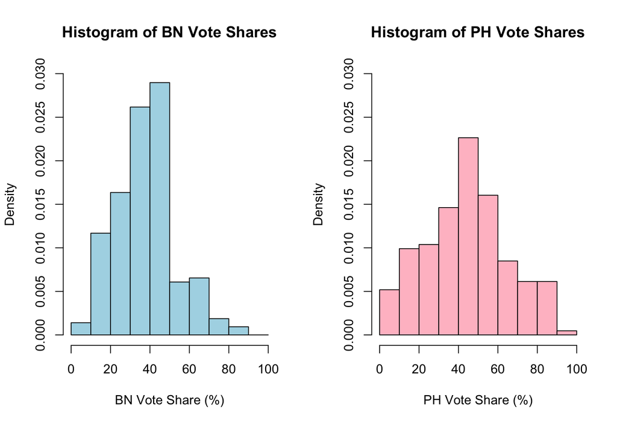

## Challenge 2 (Solution)

Histograms indicate there more variation across constituencies in what proportion votes for Pakatan Harapan than in what proportion votes for Barisan Nasional. We can also confirm by calculating the standard deviation of vote shares.

```r
sd(ge18$pctBN, na.rm = TRUE)
```

```
## [1] 15.18926
```

```r
sd(ge18$pctPH, na.rm = TRUE)
```

```
## [1] 20.82529
```

## Challenge 2 (Solution)

Create scatter plot of PH Vote Share by the proportion of voters classified as Bumiputera

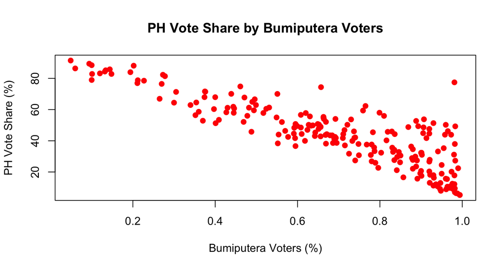

```r
plot(pctPH ~ BUMI, data=ge18, col="red", pch=19,
     xlab="Bumiputera Voters (%)", ylab="PH Vote Share (%)",
     main="PH Vote Share by Bumiputera Voters")
```

## Challenge 2 (Solution)

Estimate linear models for PH Vote Share and all ethnicities:

```r
lm18.PH.BUMI    <-lm(pctPH ~ BUMI,    data=ge18)
lm18.PH.CHINESE <-lm(pctPH ~ CHINESE, data=ge18)
lm18.PH.INDIAN  <-lm(pctPH ~ INDIAN,  data=ge18)
lm18.PH.OTHER   <-lm(pctPH ~ OTHER,   data=ge18)
```

Check the model output for `BUMI` in 2018:

```r
coef(lm18.PH.BUMI)
```

```
## (Intercept)        BUMI
##    93.31332   -71.46756
```

## Challenge 2 (Solution)

We find that Bumiputera also had the highest predictive power for Pakatan Harapan.

```r
summary(lm18.PH.BUMI)$r.squared
```

```
## [1] 0.7293721
```

```r
summary(lm18.PH.CHINESE)$r.squared
```

```
## [1] 0.6984725
```

```r
summary(lm18.PH.INDIAN)$r.squared
```

```
## [1] 0.3682286
```

```r
summary(lm18.PH.OTHER)$r.squared
```

```
## [1] 0.009369411
```

## Challenge 3

At this point it should be clear that there is a strong relationship between voting and ethnicity. But the following plot includes an interesting outlier (highlighted in red), with 77% voting for Pakatan Harapan in a district with 98% Bumiputera.

Investigate the outlier. Can you come up with an explanation why it is so different from most other constituencies?

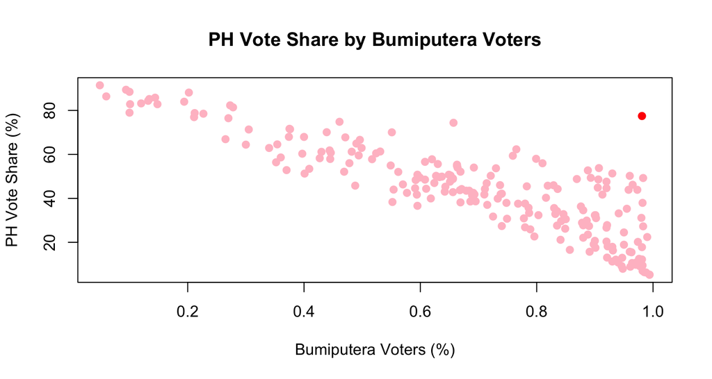

## Challenge 3 (Solution)

A quick subset will allow us to identify and investigate the outlier:

```r
ge18[which(ge18$pctPH > 70 & ge18$BUMI > 0.9),]
```

```
##     DISTNO STATE DISTNAME VOTESBN VOTESPH VOTERS TURNOUT AREA  BUMI CHINESE
## 189   P189 Sabah SEMPORNA    6135   26809  48248   34613 1177 0.981   0.016
##     INDIAN OTHER    pctBN    pctPH
## 189     NA 0.003 17.72455 77.45356
```

Interesting. The constituency is named SEMPORNA and is located in Sabah in East Malaysia.

For those who are familiar with Sabah, can you think of anything special about Sabah or what happened in the state during the 2018 election that could help us to explain why voters behaved differently than the model would predict?

## Challenge 3 - A “Sabah Effect”?

First and foremost, ethnic identity is different and more complicated in Sabah.

- Much of Sabah’s population is legally classified as Bumiputera
- But this is not the same thing as saying that people in Sabah fit into the MCIO model of race/ethnicity that shapes identity and you have talked about in CC courses like CSI.
  - Sabah only became part of Malaysia along with Sarawak (and Singapore) in 1963.
  - Prior to this, British colonialists did not use MCIO to divide and rule in Sabah as they had in Singapore and Malaya.
- The Bumiputera population of Sabah is quite diverse in terms of religion, language, and traditions:
  - Not everyone who is Bumiputera in Sabah speaks the Malay language, or is Muslim.
  - Over 42 distinct ethno-linguistic groups and 200 sub-groups.

## Challenge 3 - A “Sabah Effect”?

Second and as a result, the relationship between ethnic identity and politics is more complicated and less straight-forward in Sabah than it is in peninsular Malaysia.

Other forms of localised identity also matter for national politics:

- One’s identity as a Sabahan — one who was born in or identifies with Sabah — is arguably more important that ethnic identity in many contexts.
- Whether Bumiputera, Chinese, or Indian, you can be a Sabahan.
- If you identify as a Sabahan, then it might also affect your politics and how you vote…

## Challenge 3 - A “Sabah Effect”?

To this end, the 2018 General Election also saw the emergence of a new, multi-ethnic party in Sabah: The Sabah Heritage Party (Parti Warisan Sabah or **Warisan**).

- Warisan positioned itself as in favor of greater autonomy for Sabah.
- It also allied itself with the opposition Pakatan Harapan (PH) coalition.
- It proved to be quite popular across the state…

Let us check whether this “Sabah effect” also applies to other constituencies in Sabah.

Recreate the scatter plot of PH vote share versus Bumiputera voters with different colors for the districts outside and inside Sabah.

## Challenge 3 - A “Sabah Effect”? (Solution)

The solid red points are from Sabah while the pink ones are not.

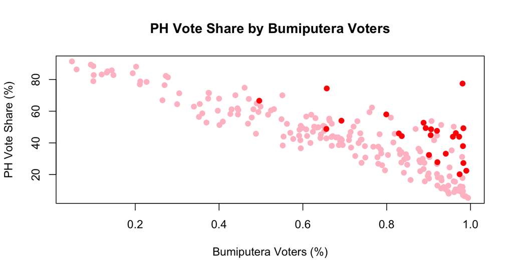

It seems that voting and ethnicity are different in Sabah as the observed PH vote share is shifted upwards from what the model would predict (i.e. leverage). But does this influence the slope?

## Challenge 3 - A “Sabah Effect”? (Solution)

Let’s assess any influence by re-estimating the relationship between PH vote share and Bumiputera voters after removing the observations from Sabah:

```r
lm18.PH.BUMI_noSBH <-lm(pctPH ~ BUMI, data = ge18[ge18$STATE != "Sabah",])
```

Now let’s re-plot the scatter plots and add the two lines of best fit. We will color the original line red and the line of best fit (with Sabah removed) in blue:

```r
plot(pctPH ~ BUMI, data = ge18[ge18$STATE != "Sabah",], col="pink", pch=19,
     xlab="Bumiputera Voters (%)", ylab="PH Vote Share (%)",
     main="PH Vote Share by Bumiputera Voters")
points(pctPH ~ BUMI, data = ge18[ge18$STATE == "Sabah",], col = "red", pch=19,
     xlab="Bumiputera Voters (%)", ylab="PH Vote Share (%)",
     main="PH Vote Share by Bumiputera Voters")
abline(lm18.PH.BUMI, col="red")        # line of best fit including Sabah
abline(lm18.PH.BUMI_noSBH, col="blue") # line of best fit excluding Sabah
```

## Challenge 3 - A “Sabah Effect”? (Solution)

Comparing the two lines shows that excluding Sabah does not influence the line of best fit by that much. Sabah constituencies are still different, but not *influential* with regards to the slope between PH vote share and Bumiputera voters.

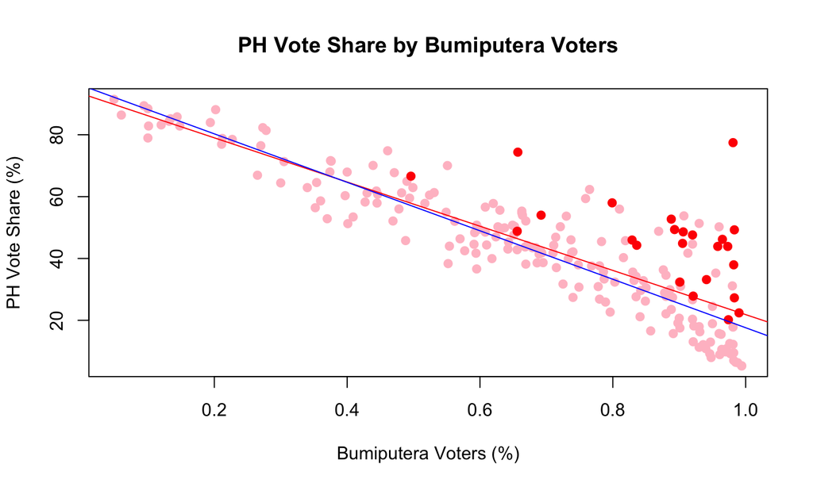

## Recap

## Recap

To recap, the learning goals for today’s class were as follows:

- Use R-squared to assess predictive power of linear models
  - We used R-squared to compare the predictive power of a variety of models to predict vote shares
- Examine the residuals from linear models
  - We used residual plots and the shape of the points to assess whether the relationship between BN vote share and ethnicity met the conditions for a linear model
  - We compared residual standard errors from a variety of models to discern which models accounted for more of the variability in BN vote share
- Think about outliers, leverage, and influence
  - We identified outliers from Sabah in the 2018 General election
  - We then showed that outliers may have high leverage, but they are not necessarily influential (i.e. they do not influence the slope by much)